# si544-day8-multiple-regression

drewpap

10/25/2019

As usual, load all the libraries that we’ll need:

```r
library(tidyverse)
library(moderndive)
library(skimr)
```

Simplify our dataset:

```r
evals_day8 <- evals %>% select(ID, score, age, gender)
```

Create a visualization of a linear regression:

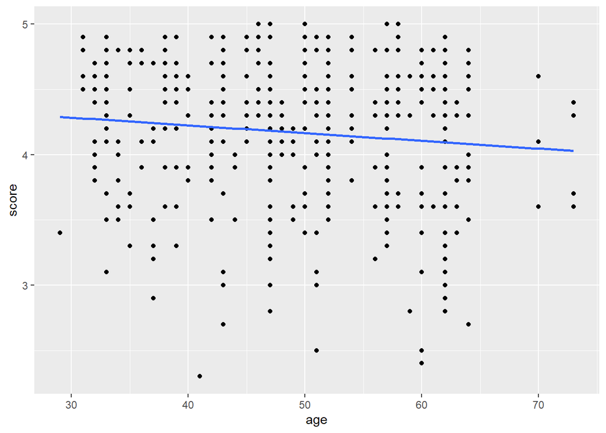

```r
evals_day8 %>% ggplot(mapping=aes(x=age,y=score)) + geom_point() + geom_smooth(method="lm",se = FALSE)
```

Add the confidence interval:

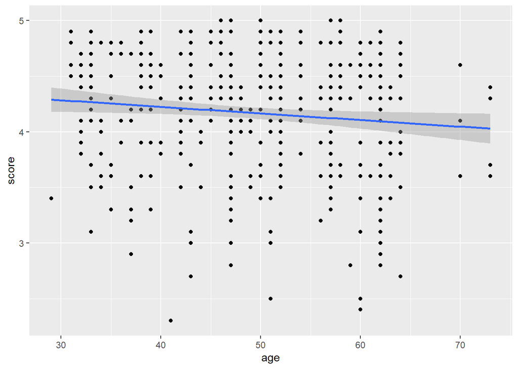

```r
evals_day8 %>% ggplot(mapping=aes(x=age,y=score)) + geom_point() + geom_smooth(method="lm",se = TRUE)
```

Create a linear model of score vs. age using a pipeline:

```r
evals_day8 %>% lm(score ~ age, data = .) %>% get_regression_table()
```

```
## # A tibble: 2 x 7
##   term      estimate std_error statistic p_value lower_ci upper_ci
##   <chr>        <dbl>     <dbl>     <dbl>   <dbl>    <dbl>    <dbl>
## 1 intercept    4.46      0.127     35.2    0        4.21     4.71
## 2 age         -0.006     0.003     -2.31   0.021   -0.011   -0.001
```

```r
#Using a pure pipeline instead of a variable
#data = . means whatever is on the left hand side of the pipeline
evals_model = lm(score ~ age, data = evals_day8)
```

```r
get_regression_table(evals_model)
```

```
## # A tibble: 2 x 7
##   term      estimate std_error statistic p_value lower_ci upper_ci
##   <chr>        <dbl>     <dbl>     <dbl>   <dbl>    <dbl>    <dbl>
## 1 intercept    4.46      0.127     35.2    0        4.21     4.71
## 2 age         -0.006     0.003     -2.31   0.021   -0.011   -0.001
```

Now let’s separate male and female:

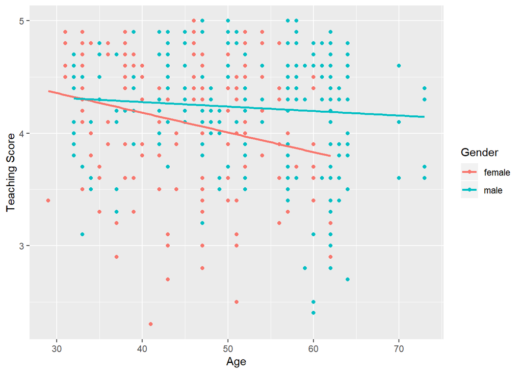

```r
ggplot(evals_day8, aes(x = age, y = score, color = gender)) +
  geom_point() +
  labs(x = "Age", y = "Teaching Score", color = "Gender") +
  geom_smooth(method="lm",se=FALSE)
```

And let’s create a linear model of score vs. age that takes gender into account:

```r
score_model_interaction <- lm(score ~ age * gender, data = evals_day8)
# Get regression table:
get_regression_table(score_model_interaction)
```

```
## # A tibble: 4 x 7
##   term           estimate std_error statistic p_value lower_ci upper_ci
##   <chr>             <dbl>     <dbl>     <dbl>   <dbl>    <dbl>    <dbl>
## 1 intercept         4.88      0.205     23.8    0        4.48     5.29
## 2 age              -0.018     0.004     -3.92   0       -0.026   -0.009
## 3 gendermale       -0.446     0.265     -1.68   0.094   -0.968    0.076
## 4 age:gendermale    0.014     0.006      2.45   0.015    0.003    0.024
```

Let’s look at the residuals:

```r
get_regression_points(score_model_interaction)
```

```
## # A tibble: 463 x 6
##       ID score   age gender score_hat residual
##    <int> <dbl> <int> <fct>      <dbl>    <dbl>
##  1     1   4.7    36 female      4.25    0.448
##  2     2   4.1    36 female      4.25   -0.152
##  3     3   3.9    36 female      4.25   -0.352
##  4     4   4.8    36 female      4.25    0.548
##  5     5   4.6    59 male        4.20    0.399
##  6     6   4.3    59 male        4.20    0.099
##  7     7   2.8    59 male        4.20   -1.40
##  8     8   4.1    51 male        4.23   -0.133
##  9     9   3.4    51 male        4.23   -0.833
## 10    10   4.5    40 female      4.18    0.318
## # ... with 453 more rows
```

Let’s take a look at a model that assumes there is no interaction:

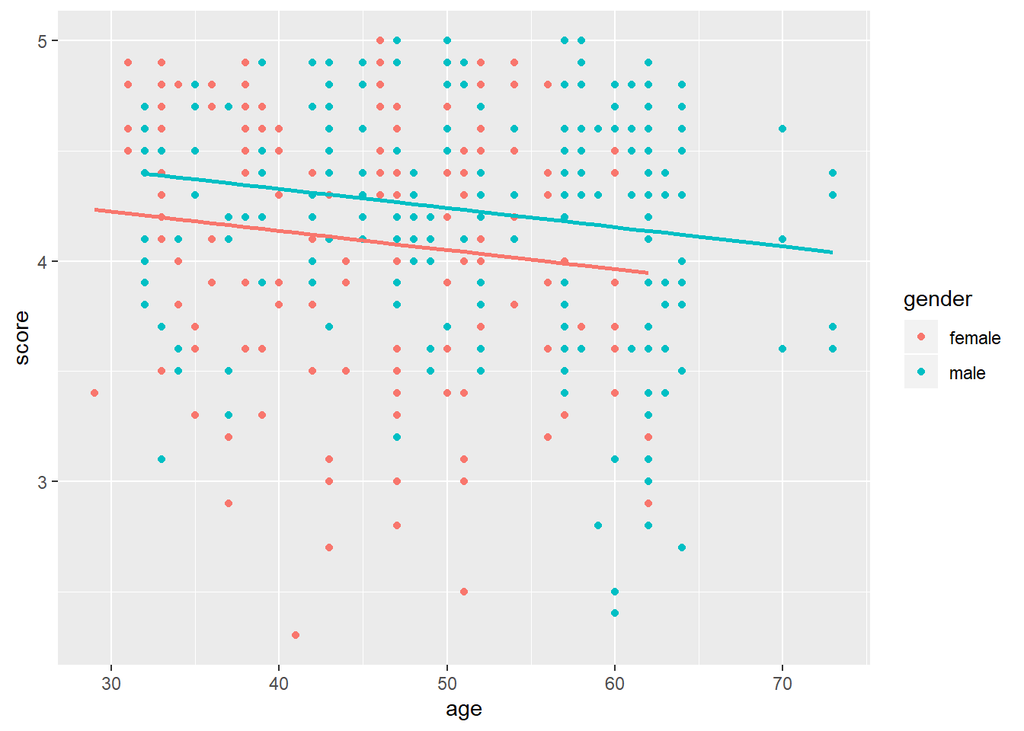

```r
gg_parallel_slopes(y = "score", num_x = "age", cat_x = "gender",
                   data = evals_day8)
```

Let’s create a regression model that does not have an interaction term (note the formula uses ‘+’ instead of ’*’):

```r
score_model_parallel_slopes <- lm(score ~ age + gender, data = evals_day8)
get_regression_table(score_model_parallel_slopes)
```

```
## # A tibble: 3 x 7
##   term       estimate std_error statistic p_value lower_ci upper_ci
##   <chr>         <dbl>     <dbl>     <dbl>   <dbl>    <dbl>    <dbl>
## 1 intercept     4.48      0.125     35.8    0        4.24     4.73
## 2 age          -0.009     0.003     -3.28   0.001   -0.014   -0.003
## 3 gendermale    0.191     0.052      3.63   0        0.087    0.294
```

Let’s load the Szeged weather data:

```r
weather <- read_csv("weatherHistory.csv")
```

## Learning Check 544.8.1:

Create a dataframe called “weather_day8” based on a random sample of 500 rows from weather that consists of only the following columns: temp (renamed from “Temperature (C)” ), apparent_temp (renamed from “Apparent Temperature ( C)”, humidity (from Humidity), and wind_speed (from “Wind Speed (km/h)”

```r
glimpse(weather)
```

```
## Observations: 96,453
## Variables: 12
## $ `Formatted Date`           <chr> "2006-04-01 00:00:00.000 +0200", "2...
## $ Summary                    <chr> "Partly Cloudy", "Partly Cloudy", "...
## $ `Precip Type`              <chr> "rain", "rain", "rain", "rain", "ra...
## $ `Temperature (C)`          <dbl> 9.472222, 9.355556, 9.377778, 8.288...
## $ `Apparent Temperature (C)` <dbl> 7.388889, 7.227778, 9.377778, 5.944...
## $ Humidity                   <dbl> 0.89, 0.86, 0.89, 0.83, 0.83, 0.85,...
## $ `Wind Speed (km/h)`        <dbl> 14.1197, 14.2646, 3.9284, 14.1036, ...
## $ `Wind Bearing (degrees)`   <dbl> 251, 259, 204, 269, 259, 258, 259, ...
## $ `Visibility (km)`          <dbl> 15.8263, 15.8263, 14.9569, 15.8263,...
## $ `Loud Cover`               <dbl> 0, 0, 0, 0, 0, 0, 0, 0, 0, 0, 0, 0,...
## $ `Pressure (millibars)`     <dbl> 1015.13, 1015.63, 1015.94, 1016.41,...
## $ `Daily Summary`            <chr> "Partly cloudy throughout the day."...
```

```r
weather_day8 <- weather %>% select(temp = "Temperature (C)", apparent_temp = "Apparent Temperature (C)", humidity = Humidity, wind_speed = "Wind Speed (km/h)") %>% sample_n(500)
weather_day8
```

```
## # A tibble: 500 x 4
##     temp apparent_temp humidity wind_speed
##    <dbl>         <dbl>    <dbl>      <dbl>
##  1 28.9         28.2       0.36      12.5
##  2 35.4         34.8       0.28       3.86
##  3  7.67         5.77      0.96      10.5
##  4 21.9         21.9       0.77       5.18
##  5  0.05        -3.07      0.92       9.35
##  6  5.02         2.47      0.76      11.1
##  7 21.1         21.1       0.73       3.03
##  8  9.82         9.47      0.8        5.31
##  9 -2.85        -2.85      0.96       3.28
## 10  2.78        -0.594     0.89      12.9
## # ... with 490 more rows
```

Let’s take a look at the relationship between apparent_temp and temp, as well as apparent_temp and humidity:

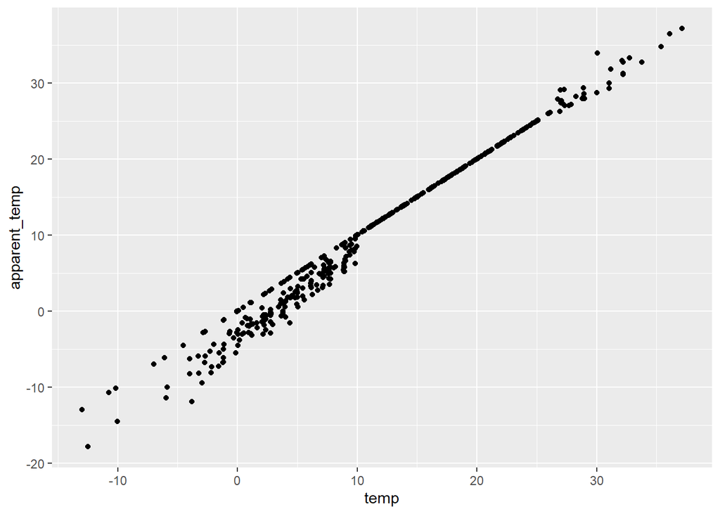

```r
ggplot(weather_day8, mapping=aes(x=temp, y=apparent_temp)) + geom_point()
```

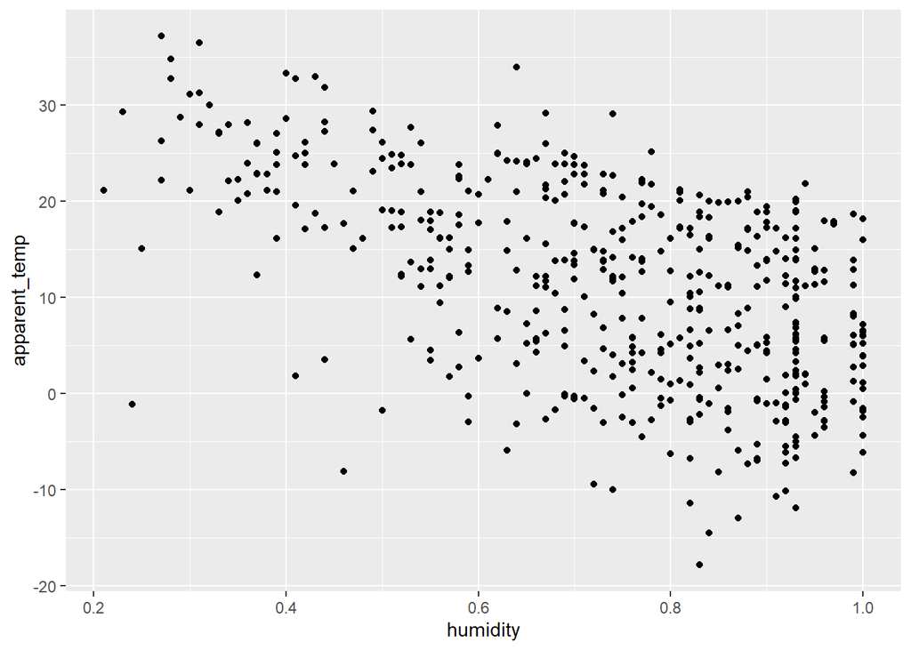

```r
ggplot(weather_day8, mapping=aes(x=humidity, y=apparent_temp)) + geom_point()
```

## Learning Check 544.8.2:

Create a regression that models “Apparent Temperature” in terms of “Temperature”. How good is your model?

```r
weather_model = lm(apparent_temp ~ temp, data = weather_day8)
get_regression_table(weather_model)
```

```
## # A tibble: 2 x 7
##   term      estimate std_error statistic p_value lower_ci upper_ci
##   <chr>        <dbl>     <dbl>     <dbl>   <dbl>    <dbl>    <dbl>
## 1 intercept    -2.37     0.094     -25.2       0    -2.55    -2.18
## 2 temp          1.11     0.006     181.        0     1.10     1.12
```

```r
get_regression_summaries(weather_model)
```

```
## # A tibble: 1 x 8
##   r_squared adj_r_squared   mse  rmse sigma statistic p_value    df
##       <dbl>         <dbl> <dbl> <dbl> <dbl>     <dbl>   <dbl> <dbl>
## 1     0.985         0.985  1.59  1.26  1.26    32855.       0     2
```

The model is seemingly very very good. 98.5% of the variance of the model is explained. However, looking at the dataset we see that some of the values between apparent temperature and temperature are exactly the same. There may be a problem in the way that the data was collected that results in an extremely high r squared value. On its face though, the model is very accurate.

Let’s look at a model of apparent_temperature that uses temp and humidity as explanatory variables:

```r
weather_model <- lm(apparent_temp ~ temp*humidity
                   ,data=weather_day8)
get_regression_table(weather_model)
```

```
## # A tibble: 4 x 7
##   term          estimate std_error statistic p_value lower_ci upper_ci
##   <chr>            <dbl>     <dbl>     <dbl>   <dbl>    <dbl>    <dbl>
## 1 intercept       -2.09      0.495    -4.23    0       -3.06    -1.12
## 2 temp             1.03      0.023    45.6     0        0.99     1.08
## 3 humidity        -0.545     0.591    -0.922   0.357   -1.70     0.616
## 4 temp:humidity    0.132     0.03      4.43    0        0.074    0.191
```

## Learning Check 544.8.3:

Create a linear regression model for apparent_temp that includes temperature, humidity, and wind speed as explanatory variables. Calculate the apparent temperature when the temperature is 20 degrees celcius, the humidity 65%, and the wind speed 20 km/h.

```r
weather_model <- lm(apparent_temp ~ temp+humidity+wind_speed,data=weather_day8)
get_regression_table(weather_model)
```

```
## # A tibble: 4 x 7
##   term       estimate std_error statistic p_value lower_ci upper_ci
##   <chr>         <dbl>     <dbl>     <dbl>   <dbl>    <dbl>    <dbl>
## 1 intercept    -1.80      0.319     -5.66   0       -2.43    -1.18
## 2 temp          1.12      0.006    173.     0        1.10     1.13
## 3 humidity      0.54      0.315      1.72   0.087   -0.078    1.16
## 4 wind_speed   -0.095     0.007    -13.1    0       -0.109   -0.081
```